# SYDE 631 Course Project: LinkCity Customer Traffic Time Series

Baoshi Sun, WatID# 20625524

Monday, November 30, 2015

## Synopsis

In the course SYDE 631 (Time Series Modelling, 2015 Fall) by Professor Keith Hipel, the rich variety of time series models that are defined, explained and illustrated. This project attemps to apply the knowledge and skills acquired from the course to solve an essential problem for retail business: the customer traffic analysis. Fresh data from a shopping mall are adopted. Seasonal model is mainly used to fit and forcast the customer traffic, cross validation is conducted, and a number of further research topics are proposed as well.

## Background

### About LinkCity

LinkCity is a middle-sized shopping mall in Suzhou, China. The 6-storeyed mall sized 600,000 square foot offers shopping, catering, cinema, gaming, supermarket, and many other retail services. In early 2015, LinkCity deployed more than 200 Wi-Fi access points, so that all business areas and parking lot are covered with Wi-Fi signal.

[figure not shown]

With the new Wi-Fi infrastructure, LinkCity offers high speed free Wi-Fi access to its customers. On the other hand, the Wi-Fi system can record a lot of useful data of users’ mobile devices, such as device presence status, dwelling duration, shopping path, phone number, device type, customer geo-distribution, and so on.

[figure not shown]

To reveal the value of these data, a few systems, for example customer grading system and recommendation system, are developed. However, they are just a small fraction of what could be studied. Much more topics still wait to be explored. One of the most important topic is the customer traffic analysis and forecast.

If we assume the number of Wi-Fi users can reflect the population of customers, we can use the statistics of Wi-Fi users to estimate the overall customer traffic.

### Motivation of Study

Althoug it is readily comprehensible that “how understanding customer traffic patterns can help good retailers become great retailers” (Mark Ryski 2011), little empirical evidence exists on the insight of store traffic characteristics (Perdikaki, O., Kesavan S., & Swaminathan J.M. 2012). In addition, because of the lack of traffic data, many studies use the number of transactions as a proxy for store traffic (e.g., Walters and Rinne 1986, Walters and MacKenzie 1988).

As the Wi-Fi users can reflect the population of retail customers, it is reasonable to perform traffic analysis on the data of Wi-Fi users. In recent years, researchers and business operators began to employ Wi-Fi data over a variaty of venues to highlight differences in traffic volumes and patterns (Ghosh, A. 2011).

On the other hand, few articles, which make use of time series to study the customer traffic, could be found. However, intuitively, given a specific venue, for example a shopping mall or a specialty store, the customer traffic should be able to be expressed as a function of time.

### Data and Methodology

In this study, the Wi-Fi user login records in LinkCity from May 1, 2015 to September 24, 2015 are obtained. For each record, we picked four data fields (variables) for traffic analysis, including:  
– “loginid”: Wi-Fi user login ID, such as phone number or social media username  
– “nasidentifier”: Wi-Fi Access Point Mac address, which can be used to determine user location  
– “callingstationId”: Wi-Fi device Mac address  
– “responsetime”: Wi-Fi user login time

During the project, the second batch of data (September 25 to the end of October) were received. These data are used for model validation. Of course, we can also combine the two batches of datasets together, re-train our models and examine the influence of the enlarged size of observations.

Considering the purpose of this project is to practise the learning in the course, time series modelling methodology, such as seasonal models, TFN, intervention analysis, etc., will be employed as much as possible.

### Reproducible Research

Besides the output article in PDF or HTML format, the work of this project can be examined and reproduced by running codes on the raw data. The codes are embeded in a R markdown file (RMD), and the raw data are stored in csv files. The RMD writeup and data files can be found in SYDE631 directory at https://github.com/sunbaoshi1975/UWStudy.git.

## Exploratory Data Analysis

### Load the Wi-Fi raw data

Each row of the raw data represents a record of a Wi-Fi user’s login operation. To narrow down the size of data table, irrelevant fields are filtered out except for the four variables those we mentioned before.

The local Weather condition data and the local CPI data are also loaded. The time spans of both datasets should be the same as the Wi-Fi raw data, say between May 1, 2015 and September 24, 2015.

### Preprocess

Since we intent to conduct a daily based time series analysis, the raw data should be preprocessed beforehand. The process consists of two major steps:  
– To trim out the data points earlier than ‘2015-05-01 00:00:01’ and later than ‘2015-09-24 23:59:59’  
– To aggregate data on daily basis and count the number of user logins in each day

Calcualte the time span of the dataset.

```
## [1] 2015-04-08 16:15:24.233
## 273841 Levels: 2015-04-08 16:15:24.233 ... 2015-09-25 09:58:14.091
```

```
## [1] 2015-09-25 09:58:14.091
## 273841 Levels: 2015-04-08 16:15:24.233 ... 2015-09-25 09:58:14.091
```

Only keep data between 2015-05-01 00:00:01 to 2015-09-24 23:59:59.

Then the detailed records are aggregated on daily basis, so that each record in the processed dataset represent the number of logins during a specific date.

Samples of login records (raw data):

```
##       loginid  nasidentifier        responsetime  LoginDate
## 1 18852404253     B1-03-0061 2015-05-01 00:42:39 2015-05-01
## 2 15186075051     B1-19-0056 2015-05-01 01:22:52 2015-05-01
## 3 15186075051     B1-19-0056 2015-05-01 01:35:23 2015-05-01
## 4 13584833983 3F-SAM-17-0104 2015-05-01 05:50:07 2015-05-01
## 5 15995897097     1F-14-0198 2015-05-01 06:35:07 2015-05-01
```

```
##            loginid nasidentifier        responsetime  LoginDate
## 270479 18915135559    B1-18-0052 2015-09-24 22:47:10 2015-09-24
## 270480 18913508781    B1-19-0056 2015-09-24 22:59:02 2015-09-24
## 270481 13801351389    3F-02-0026 2015-09-24 23:18:36 2015-09-24
## 270482 13801351389    3F-03-0217 2015-09-24 23:27:26 2015-09-24
## 270483 18699144339    3F-03-0217 2015-09-24 23:51:11 2015-09-24
```

Raw Wi-Fi login records summary:

```
## [1] "  Total rows: 270,483 from 2015-05-01 00:00:01 to 2015-09-24 23:59:59"
```

“Samples of aggregated data on daily basis:”

```
##     LoginDate count "..."  LoginDate count
## 1  2015-05-01  2437   ... 2015-09-15  1438
## 2  2015-05-02  2439   ... 2015-09-16  1607
## 3  2015-05-03  2169   ... 2015-09-17  1527
## 4  2015-05-04  1316   ... 2015-09-18  1763
## 5  2015-05-05  1369   ... 2015-09-19  2395
## 6  2015-05-06  1240   ... 2015-09-20  2062
## 7  2015-05-07  1139   ... 2015-09-21  1276
## 8  2015-05-08  1268   ... 2015-09-22  1294
## 9  2015-05-09  1754   ... 2015-09-23  1301
## 10 2015-05-10  1756   ... 2015-09-24  1390
```

```
##    LoginDate              count
##  Min.   :2015-05-01   Min.   :1052
##  1st Qu.:2015-06-06   1st Qu.:1484
##  Median :2015-07-13   Median :1775
##  Mean   :2015-07-13   Mean   :1840
##  3rd Qu.:2015-08-18   3rd Qu.:2146
##  Max.   :2015-09-24   Max.   :3176
```

A rough summary of the daily traffic can be seen above. There are totally 270,483 login records throughout 147 days or 21 weeks.

### Plotting

From the plot of daily number of Wi-Fi users below, we can observe some characteristics:  
– Nontationary, which can also be verified by seansonal Mann-Kendall test  
– Periodic on weekly basis  
– Some exterem values, e.g. around May 1 and June 27

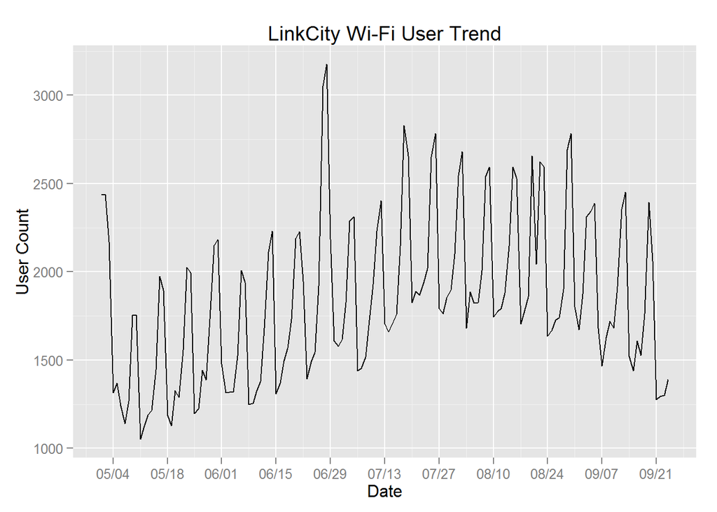

Apply seanonal Mann-Kendall test to check the trend:

```r
SeasonalMannKendall(ts.df)
```

```
## tau = 0.41, 2-sided pvalue =6.3027e-12
```

The test result indicates a significant upward trend.

In addition, using the decompose() function, we can roughly break the data series into three parts: the trend component, the seasonal comonent and the white noise. In other words, we assume:
$$Output = Trend + Seanonal + Noise$$
where the output is the time series of Wi-Fi user data

By examining the plots of the decomposition of additive time series, the three characteristics get strong support.

Moreover, the nontationary trend appears to be a curve, which may be assumed as a longer seasonal circle, e.g. monthly or quarterly. From the physical point of view, the monthly or quarterly pattern of traffic somehow holds its stand. With more observations collected in the future, we can perform seasonal analysis on monthly and quarterly basis.

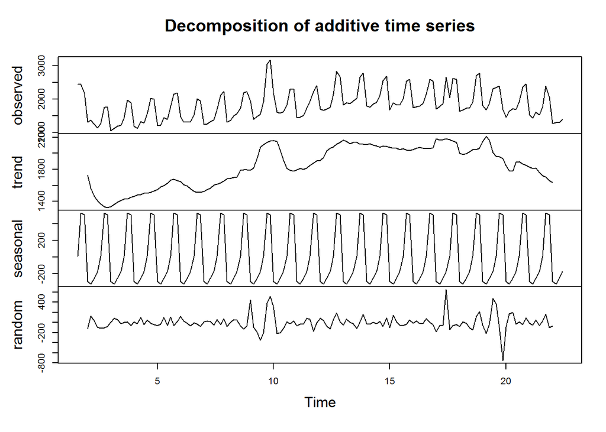

To examine the data of each day througout a week, Box-and-whisker graphs are plotted out. From the plots, we can assume that the distributions of all means are normal and logarithmic transformation is not necessary.

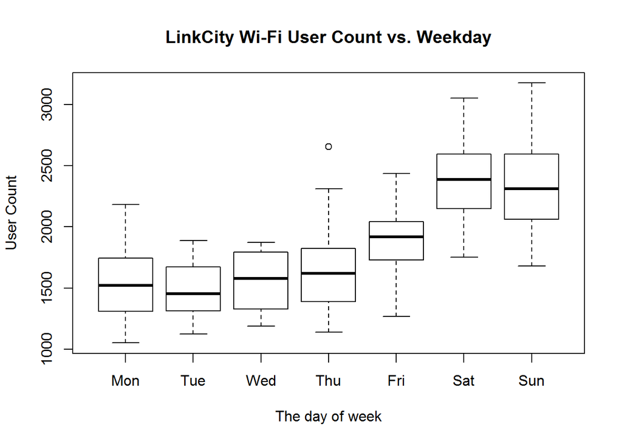

## Hypotheses

By putting the exploratory data analysis and the empirical understanding of retail customer traffic together, the following hypotheses are proposed.  
1. Traffic is a seasonal ARMA on weekly basis  
2. Traffic = Day of week + Weather Condition + CPI + Noise, where the day of week could be considered as a pulse intervention,  
3. Intervention analysis can be employed for special events, like marketing promotion, major holidays and extreme weather.  
4. The nonstationary part could be caused by external invention or a larger seasonal factor (monthly or quarterly).

In this project, we are going to focus on the first hypothesis. As the test of the other hypotheses require extra external data and more observations, we will save them for future study once the necessary data are collected.

[figure not shown]

## Seasonal Model

### Model identification

As introduced in the course, there are a couple of candidates of seasonal models, including SARIMA, deseasonalized models, periodic models, etc.

Since it is obvious that the time series in this project follows a periodic pattern on weekly basis, in order to figure out the suitable seasonal method, the dataset is divided into seven subsets corresponding to the data on Monday to Sunday respectively. The plots of their ACF and PACF are illustrated below.

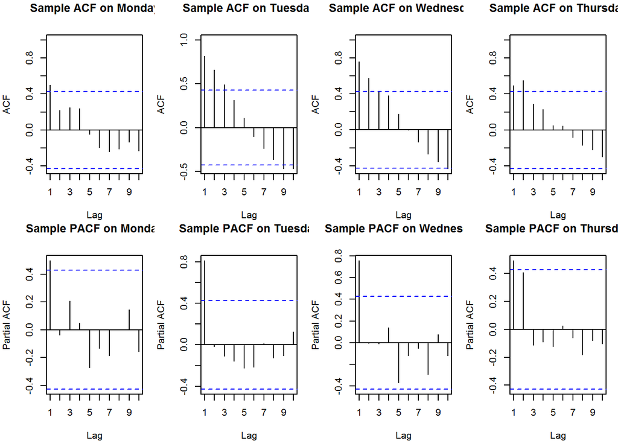

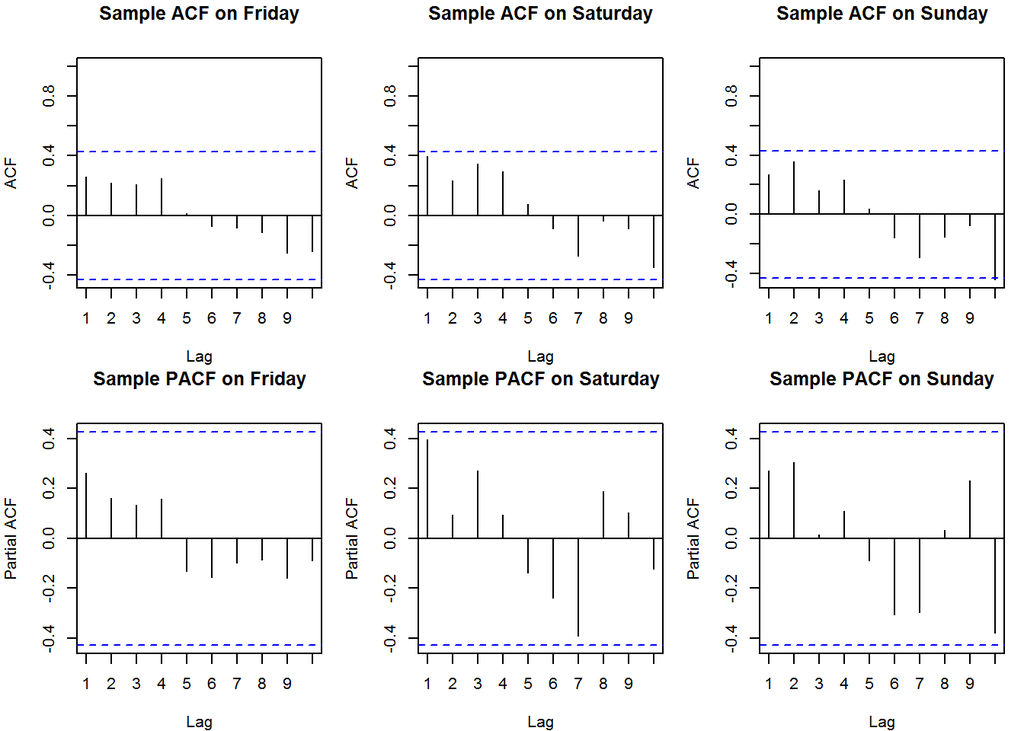

As we can see, for Monday to Thursday, the PACFs cut off at lag 1 and the ACFs die off from order 1 to 3. For Saturday, both ACF and PACF at lag 1 are only close to the significant confidence interval. The large value of PACF at lag 7 can be interpreted as external intervention. However, for Friday and Sunday, we can not obeserve any significant correlation. If we are not able construct separated models for Firday and Sunday, it is hard to apply periodic models. One possibe interpretion to this problem is that the correlation between the day and the day before it is much stronger than the correlation between the day and the day in previous week.

Furthermore, although deseasonalized models can reduce the number of paramters, it may not a good option in this case either considering the data points are not sufficent enough. Nevertheless, as the data are kept bringing in, we can apply deseasonalized model in the future.

On the other hand, the SARIMA turns out to be a proper choice. From the exploratory data analysis we performed, it is reasonable to assume the correlation within a week or across seasons is the same.

### Parameters estimation

By taking the advantage of the auto.ariam function in the forecast package of R, which provides a shortcut of seasonal ARIMA model identification, we can quickly try and test quite a few combinations of SARIMA parameters and pick a proper the one with the MLE or minimum AIC.

[output not shown]

The result show a suitable model may be
$$SARIMA(2, 1, 1)\times(2, 0, 0)_{7}$$

The lambada of Box-Cox transformation is 0.1, and the value of AIC equals to -16.38. The coefficients and their standard errors are shown above. In addition, the number of processes for both seanonal and nonseanonal components apparently conform to the ACF and PACF plots.

### Diagnostic checks

#### Whiteness Check

The residual plot and the residual autocorrelation function (RACF with 95% confidence limits) plot are drawn below.

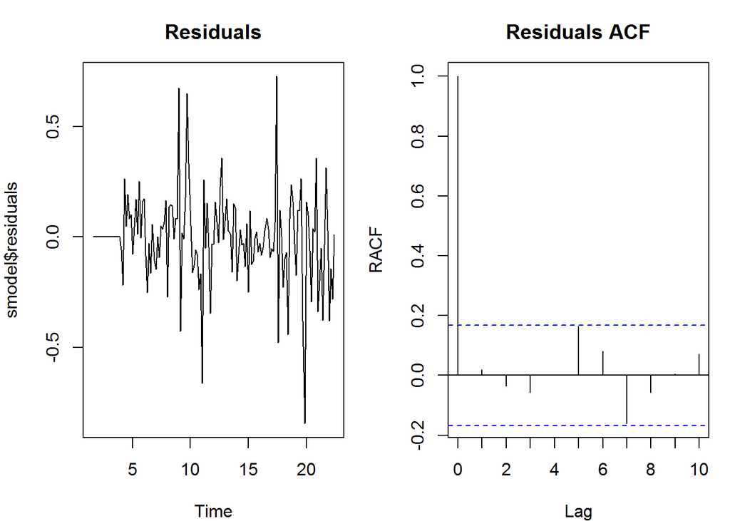

Ljung-Box test, a.k.a portmanteau test, is conducted to check the whiteness.

```r
Box.test(smodel$residuals, type="Ljung-Box", lag=10)
```

```
##
##  Box-Ljung test
##
## data:  smodel$residuals
## X-squared = 11.303, df = 10, p-value = 0.3344
```

The p-value is larger than 0.05, which means the residual can be considered as whiteness.

#### Normality Check

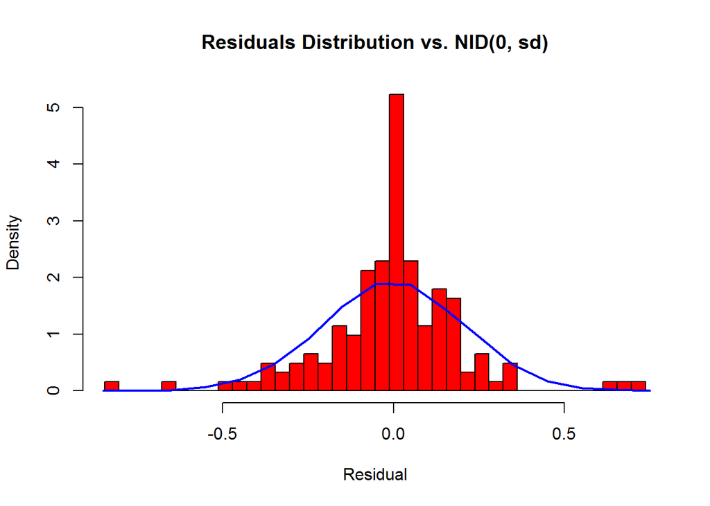

```r
ad.test(smodel$residuals)
```

```
##
##  Anderson-Darling normality test
##
## data:  smodel$residuals
## A = 3.1868, p-value = 5.04e-08
```

The graphical method displays an approximate normal distribution. However, the Anderson-Darling test rejected the hypothesis of normality. One of the possibility is the size of observations is not large enough.

#### Homoscedasticity Check

The residual plot shows the variances are nearly constant over time.

In summary, the fitted SARIMA model can be considered to have passed the diagnostic check.

## Forecasting and Validation

### Forecasting

With the fitted SARIMA model, we performs a 4-weeks-ahead forecast (from Sep 25 to Oct 22, 2015) and plots the results with 80% and 95% confidence intervals. The inversed Box-cox transformation is conducted automatically.

```
##          Point Forecast     Lo 80    Hi 80     Lo 95    Hi 95
## 22.57143       1650.849 1443.4123 1884.740 1343.3816 2020.261
## 22.71429       2122.242 1823.1891 2464.740 1680.7498 2665.496
## 22.85714       2047.449 1746.8391 2393.841 1604.3514 2597.796
## 23.00000       1350.325 1141.3747 1593.094 1042.9810 1736.906
## 23.14286       1328.700 1121.4132 1569.856 1023.9058 1712.852
## 23.28571       1401.792 1183.2950 1655.952 1080.5027 1806.644
## 23.42857       1411.147 1190.6615 1667.721 1086.9663 1819.888
## 23.57143       1622.171 1352.0512 1939.926 1226.1049 2129.880
## 23.71429       2076.265 1728.3960 2485.925 1566.3397 2731.016
## 23.85714       1911.815 1584.9393 2298.159 1433.1061 2529.919
## 24.00000       1287.661 1057.7471 1561.614  951.6427 1726.929
## 24.14286       1286.574 1055.6839 1561.957  949.2128 1728.254
## 24.28571       1320.240 1082.9031 1603.408  973.4877 1774.446
## 24.42857       1363.412 1118.1438 1656.082 1005.0843 1832.876
## 24.57143       1563.974 1253.7322 1941.678 1113.0114 2173.198
## 24.71429       1948.590 1554.3670 2430.621 1376.1786 2727.023
## 24.85714       1849.612 1467.1712 2319.546 1294.9944 2609.542
## 25.00000       1293.306 1014.5179 1639.244  889.9968 1854.240
## 25.14286       1283.601 1004.8680 1630.085  880.5508 1845.697
## 25.28571       1329.359 1040.0325 1689.211  911.0484 1913.232
## 25.42857       1352.114 1056.8643 1719.629  925.3255 1948.553
## 25.57143       1527.264 1178.7477 1965.926 1024.8719 2241.363
## 25.71429       1876.761 1445.8933 2419.927 1255.9014 2761.369
## 25.85714       1768.155 1354.8439 2291.673 1173.2980 2621.891
## 26.00000       1268.762  960.8127 1662.859  826.6788 1913.287
## 26.14286       1264.125  955.1994 1660.232  820.8514 1912.284
## 26.28571       1298.368  980.0227 1706.935  841.6844 1967.091
## 26.42857       1326.804 1000.4030 1746.107  858.6736 2013.280
```

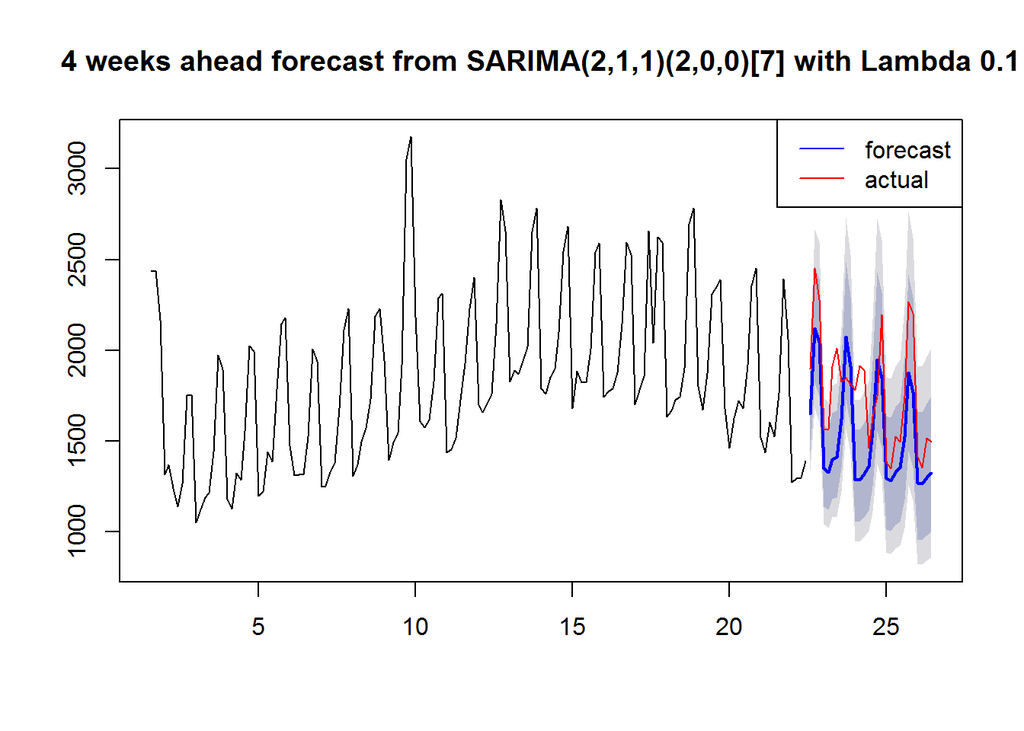

### Validation

```
##       Date         Forecast           Actual diff%
##  [1,] "2015-09-25" "1650.84855730869" "1898" "13.0%"
##  [2,] "2015-09-26" "2122.24190975323" "2451" "13.4%"
##  [3,] "2015-09-27" "2047.44873246204" "2279" "10.2%"
##  [4,] "2015-09-28" "1350.32506160239" "1563" "13.6%"
##  [5,] "2015-09-29" "1328.70013696719" "1569" "15.3%"
##  [6,] "2015-09-30" "1401.7917587342"  "1913" "26.7%"
##  [7,] "2015-10-01" "1411.14659132319" "2013" "29.9%"
##  [8,] "2015-10-02" "1622.17118672945" "1829" "11.3%"
##  [9,] "2015-10-03" "2076.26456882833" "1850" "12.2%"
## [10,] "2015-10-04" "1911.81482813616" "1814" "5.4%"
## [11,] "2015-10-05" "1287.66128575741" "1781" "27.7%"
## [12,] "2015-10-06" "1286.57350475672" "1914" "32.8%"
## [13,] "2015-10-07" "1320.24035934444" "1892" "30.2%"
## [14,] "2015-10-08" "1363.41221216393" "1462" "6.7%"
## [15,] "2015-10-09" "1563.97439832318" "1636" "4.4%"
## [16,] "2015-10-10" "1948.58985772269" "1750" "11.3%"
## [17,] "2015-10-11" "1849.612334295"   "2198" "15.9%"
## [18,] "2015-10-12" "1293.30636846278" "1385" "6.6%"
## [19,] "2015-10-13" "1283.60078524992" "1349" "4.8%"
## [20,] "2015-10-14" "1329.3590275533"  "1528" "13.0%"
## [21,] "2015-10-15" "1352.11410624038" "1498" "9.7%"
## [22,] "2015-10-16" "1527.26438067683" "1747" "12.6%"
## [23,] "2015-10-17" "1876.761049216"   "2269" "17.3%"
## [24,] "2015-10-18" "1768.15539883257" "2207" "19.9%"
## [25,] "2015-10-19" "1268.76210618876" "1419" "10.6%"
## [26,] "2015-10-20" "1264.12525882463" "1352" "6.5%"
## [27,] "2015-10-21" "1298.36794513729" "1518" "14.5%"
## [28,] "2015-10-22" "1326.80443547246" "1496" "11.3%"
```

The overall forecast accuracy inclusive of the golden week holiday:

```
##                ME     RMSE      MAE     MPE     MAPE      ACF1 Theil's U
## Test set 230.3058 314.4064 267.6393 12.4641 14.53344 0.3521027  1.021222
```

On the other hand, considering the forecasted period is very close to the golden week for Chinese National Day, intervention factors should have been introduced in the reality. In order to fit a better model, more training data those cover similar situation should be included. So if we screen off the data around the golden week (bewteen Sep 30 and Oct 7), the forecast accuracy of the rest date should be better.

The forecast accuracy excluded the golden week holiday:

```r
normalDateIndex <- c(1:5, 14:28)
accuracy(smodel.forecasts$mean[normalDateIndex], test.ts[normalDateIndex])
```

```
##                ME     RMSE      MAE      MPE     MAPE
## Test set 188.0113 232.0323 207.8703 10.39937 11.53417
```

```r
tResult <- t.test(smodel.forecasts$mean[normalDateIndex], test.ts[normalDateIndex]);tResult
```

```
##
##  Welch Two Sample t-test
##
## data:  smodel.forecasts$mean[normalDateIndex] and test.ts[normalDateIndex]
## t = -1.8259, df = 36.522, p-value = 0.07606
## alternative hypothesis: true difference in means is not equal to 0
## 95 percent confidence interval:
##  -396.74296   20.72037
## sample estimates:
## mean of x mean of y
##  1540.689  1728.700
```

As we can see, the accuracy of the forecast from 2015-09-25 to 2015-09-29, and from 2015-10-08 to 2015-10-22 is acceptable. The t-test of 95% confidence interval shows no significant difference (p-value = 0.0761 > 0.05 ) in means between the forecasts and the true values.

## Conclusion

Customer traffic analysis is very impotant to retailers. The customer traffic presents strong correlation with time. But the time series modelling methods are rarely used in the customer traffic research before.

By applying basic time series methodology on the traffic data from a shopping mall, this course project demostrated the feasibility of this approach. Although the forecast accuracy is not perfect at this moment, the results are acceptable in the off-golen-week days. We are confident of the output can be improved by bringing in more data later.

In addition, a lot of future research directions are also discussed. We believe that time series modelling has enormous application opportunities in retail industry.

## Future Study Topics

The project is just a debut of customer traffic analysis for LinkCity. In fact, there are plenty of topics need to be researched in the feature. Some of them are listed below. 1. Model refining with more observations  
2. Monthly trend analysis by accumulating more data  
3. Interventaion analysis, including wheather, CPI, etc.  
The weather condition and CPI data come from public sources. The historic weather data of Suzhou contain temperature, wind, precipitation and air quality, which can be found at http://lishi.tianqi.com/suzhou/. ANd the CPI data of suzhou was excerpted from the URL at http://lishi.tianqi.com/suzhou/. But only monthly CPI data are available.  
4. Traffic distribution analysis by floor and zone  
5. Traffic versus sales volume by zone and store  
6. Customer in-store dwelling duration (may also has seasonal character)  
7. Trend of revisiting customers in one month or one week  
8. Multi-location Traffic Analysis. LinkCity has several other shopping malls in the same city. If we can also collect the data from another shopping mall, CARMA model probably can be used for multi-location analysis.

## References

Ghosh, A., Jana, R., Ramaswami, V., Rowland, J., & Shankaranarayanan, N. K. (2011). Modeling and characterization of large-scale Wi-Fi traffic in public hot-spots. In 2011 Proceedings IEEE INFOCOM (pp. 2921-2929). http://doi.org/10.1109/INFCOM.2011.5935132

Ark Ryski. (2011). When retail customers count. Bloomington, Indiana: Author House

Perdikaki O, Kesavan S, Swaminathan JM. Effect of traffic on sales and conversion rates of retail stores. Manufacturing Service Oper. Management (2012) 14(1):145-162 Abstract

R in Time Series: Holt-Winters Smoothing and Forecast. (n.d.). Retrieved from http://www.quantlego.com/howto/holt-winters-smoothing-and-forecast/

Retail Customer Traffic Counters In Retail Analytics | SenSource. (n.d.). Retrieved December 1, 2015, from http://sensourceinc.com/blog/retail-customer-traffic-counters-plays-vital-role-in-retail-analytics/

Time Series Analysis: Building a model on non-stationary time series. (n.d.). Retrieved from http://www.r-bloggers.com/time-series-analysis-building-a-model-on-non-stationary-time-series/